# Exercise week 11

Shawn Schneidereit

2021-06-24

# 12H1

In 2014, a paper was published that was entitled “Female hurricanes are deadlier than male hurricanes As the title suggests,the paper claimed that hurricanes with female names have caused greater loss of life, and the explanation given is that people unconsciously rate female hurricanes as less dangerous and so are less likely to evacuate. Statisticians severely criticized the paper after publication. Here, you’ll explore the complete data used in the paper and consider the hypothesis that hurricanes with female names are deadlier. Load the data with:

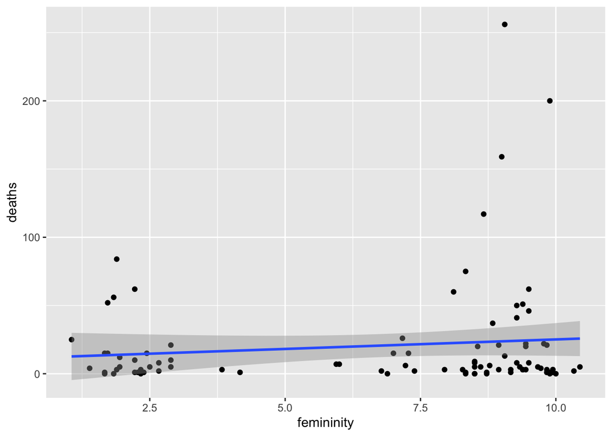

```r
library(rethinking)
data(Hurricanes)
?Hurricanes

ggplot(Hurricanes, aes(femininity, deaths)) +
  geom_point() +
  geom_smooth(method = "lm")
```

```r
# Just based off a cheap and dirty lm, there seems to be a slight potential of a trend...
```

Acquaint yourself with the columns by inspecting the help ?Hurricanes. In this problem, you’ll focus on predicting deaths using femininity of each hurricane’s name. Fit and interpret the simplest possible model, a Poisson model of deaths using femininity as a predictor. You can use quap or ulam. Compare the model to an intercept-only Poisson model of deaths. How strong is the association between femininity of name and deaths? Which storms does the model fit (retrodict) well? Which storms does it fit poorly?

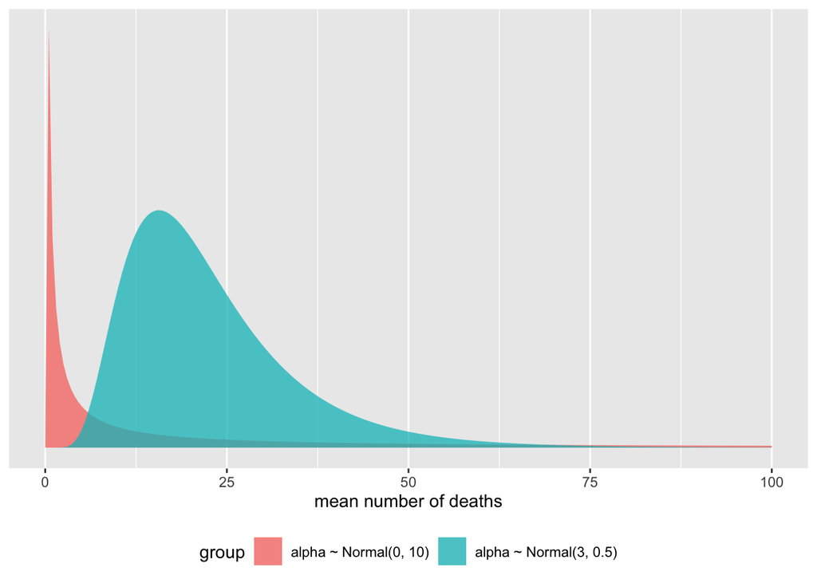

```r
# some potential prior vis
tibble(x       = c(0, 12),  # rough estimates from the data
       y       = c(0, 250), # rough estimates from the data
       meanlog = c(0, 3),
       sdlog   = c(10, 0.5)) %>%
  expand(nesting(x, y, meanlog, sdlog),
         number = seq(from = 0, to = 100, length.out = 200)) %>%
  mutate(density = dlnorm(number, meanlog, sdlog),
         group   = str_c("alpha ~ Normal(", meanlog, ", ", sdlog, ")")) %>%

  ggplot(aes(fill = group, color = group)) +
  geom_area(aes(x = number, y = density),
            alpha = 3/4, size = 0, position = "identity") +
  scale_y_continuous(NULL, breaks = NULL) +
  xlab("mean number of deaths") +
  theme(legend.position = "bottom")
```

A quick excercise to check the vailidity of the priors

Now to running the Model

```r
# intercept only
b12.1 <-
  brm(data = Hurricanes,
      family = poisson,
      deaths ~ 1,
      prior(normal(3, 0.5), class = Intercept),
      iter = 2000, warmup = 1000, chains = 4, cores = 4,
      seed = 42)

# Including femininity
b12.1b <-
  brm(data = Hurricanes,
      family = poisson,
      deaths ~ femininity,
      prior = c(prior(normal(3, 0.5), class = Intercept),
                prior(normal(0, 0.2))),
      iter = 2000, warmup = 1000, chains = 4, cores = 4,
      seed = 42)
```

```r
pp_check(b12.1)
```

```
## Using 10 posterior samples for ppc type 'dens_overlay' by default.
```

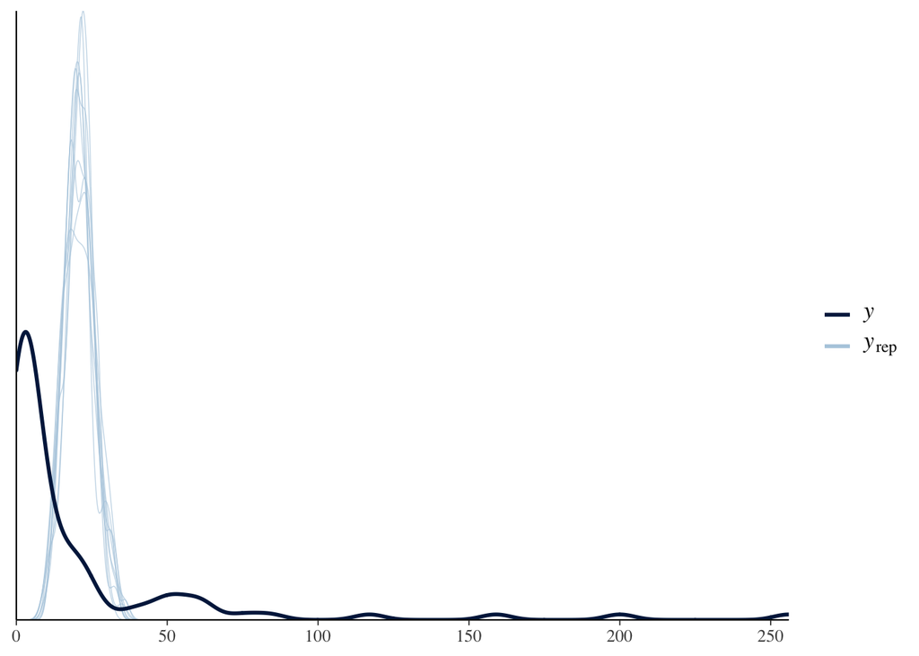

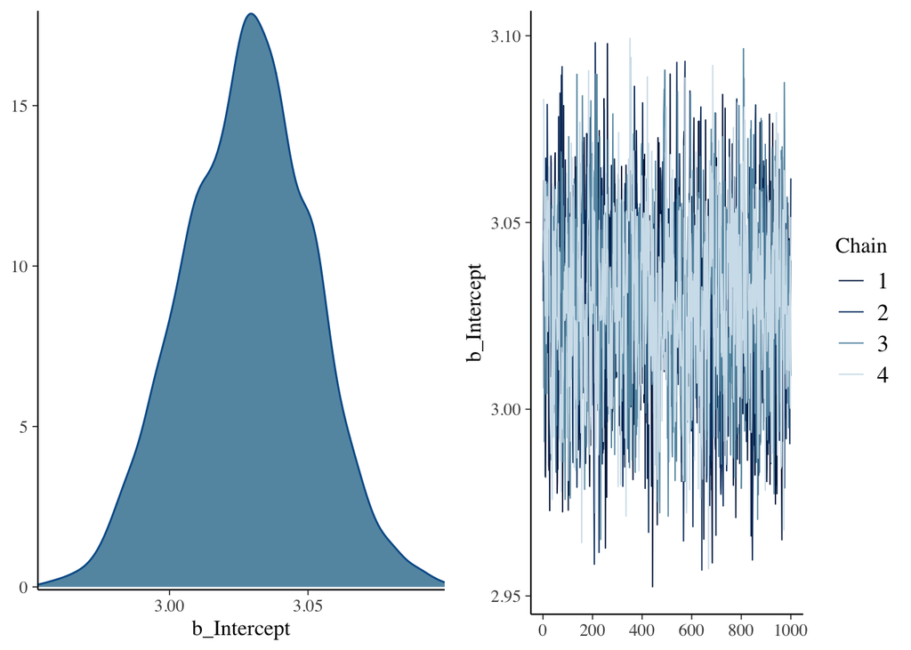

```r
plot(b12.1)
```

```r
summary(b12.1)
```

```
##  Family: poisson
##   Links: mu = log
## Formula: deaths ~ 1
##    Data: Hurricanes (Number of observations: 92)
## Samples: 4 chains, each with iter = 2000; warmup = 1000; thin = 1;
##          total post-warmup samples = 4000
##
## Population-Level Effects:
##           Estimate Est.Error l-95% CI u-95% CI Rhat Bulk_ESS Tail_ESS
## Intercept     3.03      0.02     2.98     3.07 1.00     1397     2376
##
## Samples were drawn using sampling(NUTS). For each parameter, Bulk_ESS
## and Tail_ESS are effective sample size measures, and Rhat is the potential
## scale reduction factor on split chains (at convergence, Rhat = 1).
```

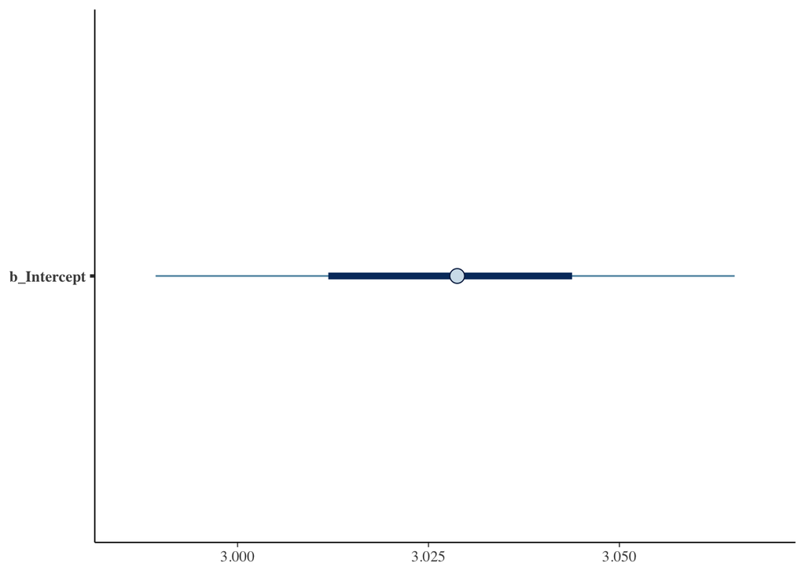

```r
mcmc_plot(b12.1, pars = "^b_")
```

```r
pp_check(b12.1b)
```

```
## Using 10 posterior samples for ppc type 'dens_overlay' by default.
```

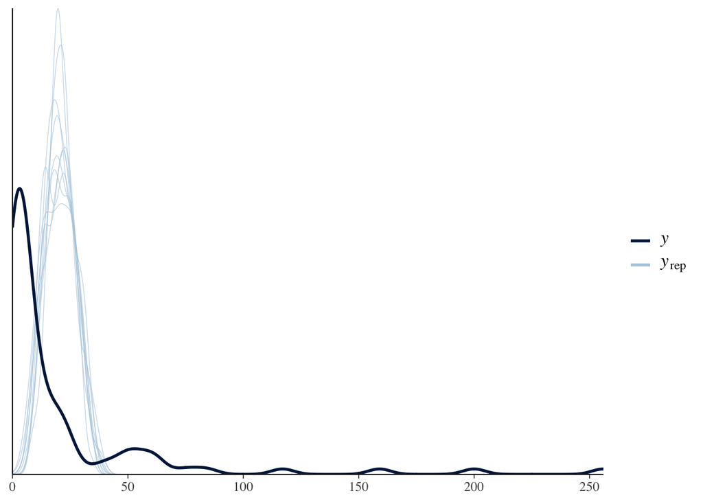

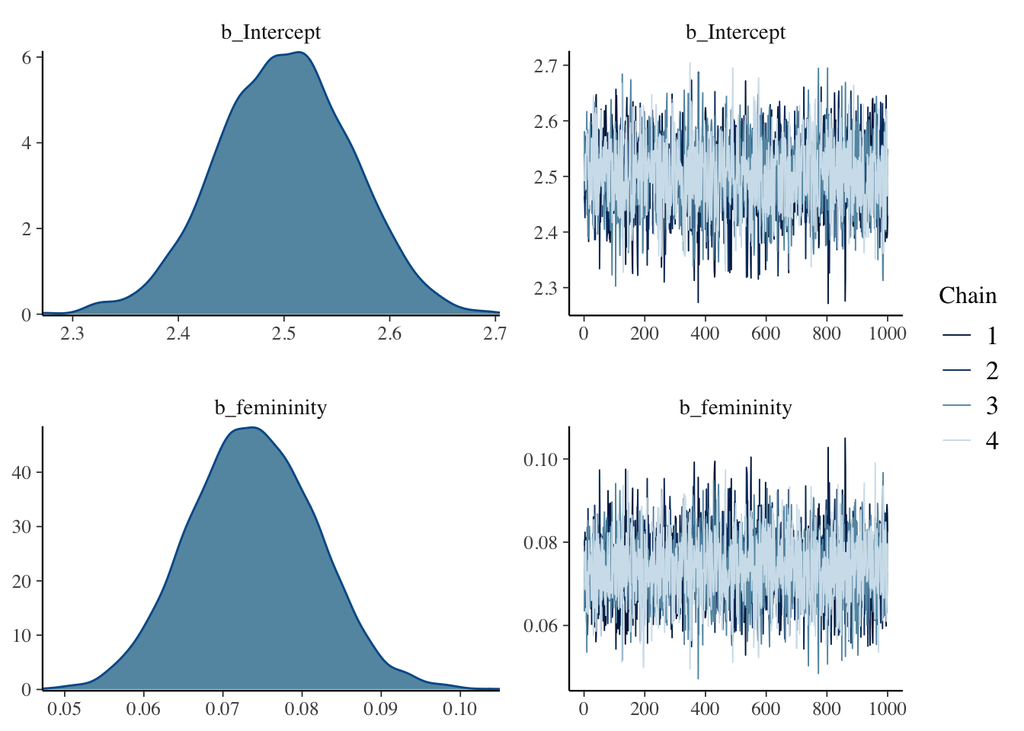

```r
plot(b12.1b)
```

```r
summary(b12.1b)
```

```
##  Family: poisson
##   Links: mu = log
## Formula: deaths ~ femininity
##    Data: Hurricanes (Number of observations: 92)
## Samples: 4 chains, each with iter = 2000; warmup = 1000; thin = 1;
##          total post-warmup samples = 4000
##
## Population-Level Effects:
##            Estimate Est.Error l-95% CI u-95% CI Rhat Bulk_ESS Tail_ESS
## Intercept      2.50      0.06     2.37     2.62 1.00     2324     2274
## femininity     0.07      0.01     0.06     0.09 1.00     2831     2343
##
## Samples were drawn using sampling(NUTS). For each parameter, Bulk_ESS
## and Tail_ESS are effective sample size measures, and Rhat is the potential
## scale reduction factor on split chains (at convergence, Rhat = 1).
```

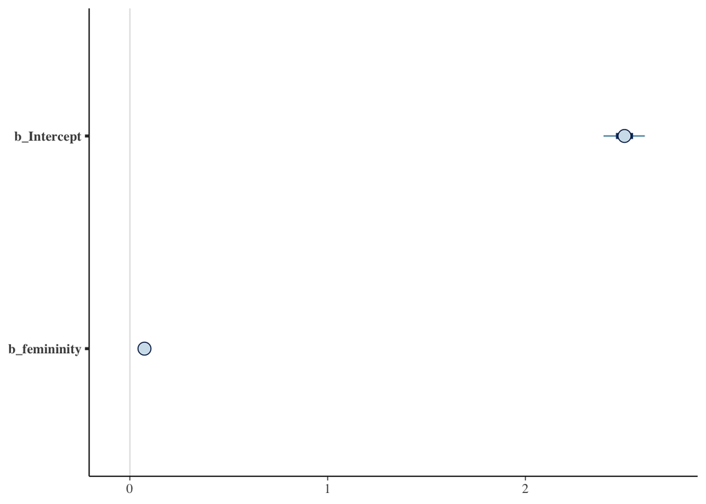

```r
mcmc_plot(b12.1b, pars = "^b_")
```

```r
b12.1 <- add_criterion(b12.1, criterion = "loo")
b12.1b <- add_criterion(b12.1b, criterion = "loo")
b_loo <- loo_compare(b12.1, b12.1b, criterion = "loo")

print(b_loo, simplify = F)
```

```
##        elpd_diff se_diff elpd_loo se_elpd_loo p_loo   se_p_loo looic   se_looic
## b12.1b     0.0       0.0 -2197.1    495.6       122.1    42.0   4394.1   991.1
## b12.1    -16.3      70.7 -2213.4    533.4        67.6    26.6   4426.8  1066.8
```

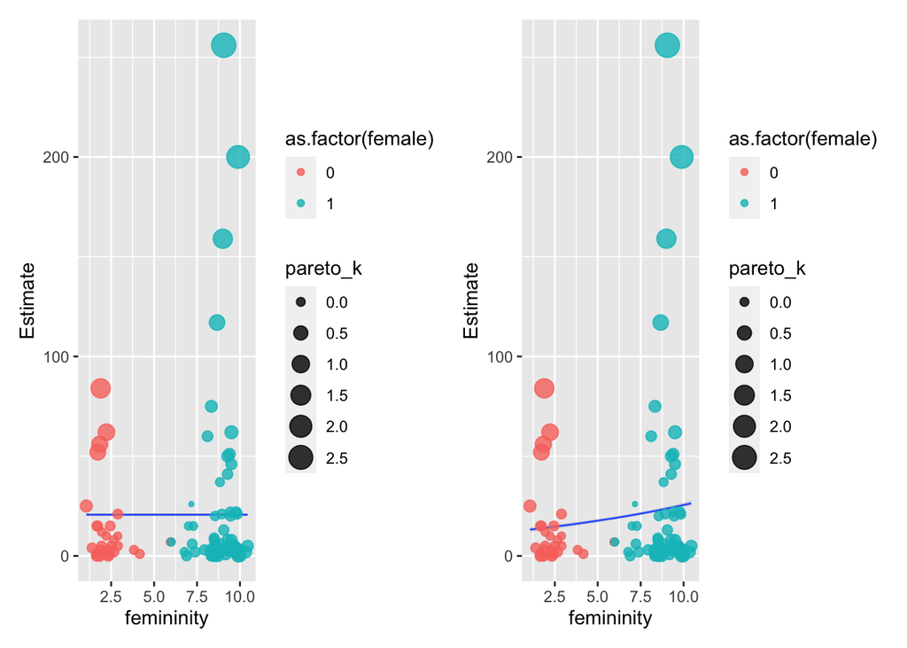

```r
# determine the range of `a` values we'd like to feed into `fitted()`
nd <-
  Hurricanes %>%
  distinct(deaths, femininity)



post_predict <- fitted(b12.1,
         newdata = nd,
         probs = c(0.055,0.945)) %>%
  data.frame() %>%
  bind_cols(nd) %>%
     mutate(row = row_number())

 post_predict_b<- fitted(b12.1b,
         newdata = nd,
         probs = c(0.055,0.945)) %>%
  data.frame() %>%
  bind_cols(nd) %>%
     mutate(row = row_number())


p1 <- post_predict %>%
  ggplot(aes(x = femininity)) +
  geom_smooth(aes(y = Estimate, ymin = Q5.5, ymax = Q94.5),
              stat = "identity",
              alpha = 1/4, size = 1/2) +
  geom_point(data = bind_cols(Hurricanes, b12.1b$criteria$loo$diagnostics),
             aes(y = deaths, size = pareto_k, color =as.factor(female)),
             alpha = 4/5)

p2 <- post_predict_b %>%
  ggplot(aes(x = femininity)) +
  geom_smooth(aes(y = Estimate, ymin = Q5.5, ymax = Q94.5),
              stat = "identity",
              alpha = 1/4, size = 1/2) +
  geom_point(data = bind_cols(Hurricanes, b12.1b$criteria$loo$diagnostics),
             aes(y = deaths, size = pareto_k, color =as.factor(female)),
             alpha = 4/5)

(p1 | p2)
```

The association between femininity and deaths is not strongly influential, but seems to explain some of the trend at least (with a 95 CI that does not cross zero). Overall it fit more moderate storms better than more extreme one, where it completely fails to account for the variations of potential numbers in the total their death numbers totals.

# 12H2

Counts are nearly always over-dispersed relative to Poisson. So fit a gamma-Poisson (aka negative-binomial) model to predict deaths using femininity. Show that the over-dispersed model no longer shows as precise a positive association between femininity and deaths, with an 89% interval that overlaps zero. Can you explain why the association diminished in strength?

```r
b12H2 <-
  brm(data = Hurricanes,
      family = negbinomial,
       deaths ~ femininity,
      prior = c(prior(normal(3, 0.5), class = Intercept),  # beta_0
                prior(exponential(1), class = shape)),  # alpha
      iter = 2000, warmup = 1000, cores = 4, chains = 4,
      seed = 42)
```

```r
pp_check(b12H2)
```

```
## Using 10 posterior samples for ppc type 'dens_overlay' by default.
```

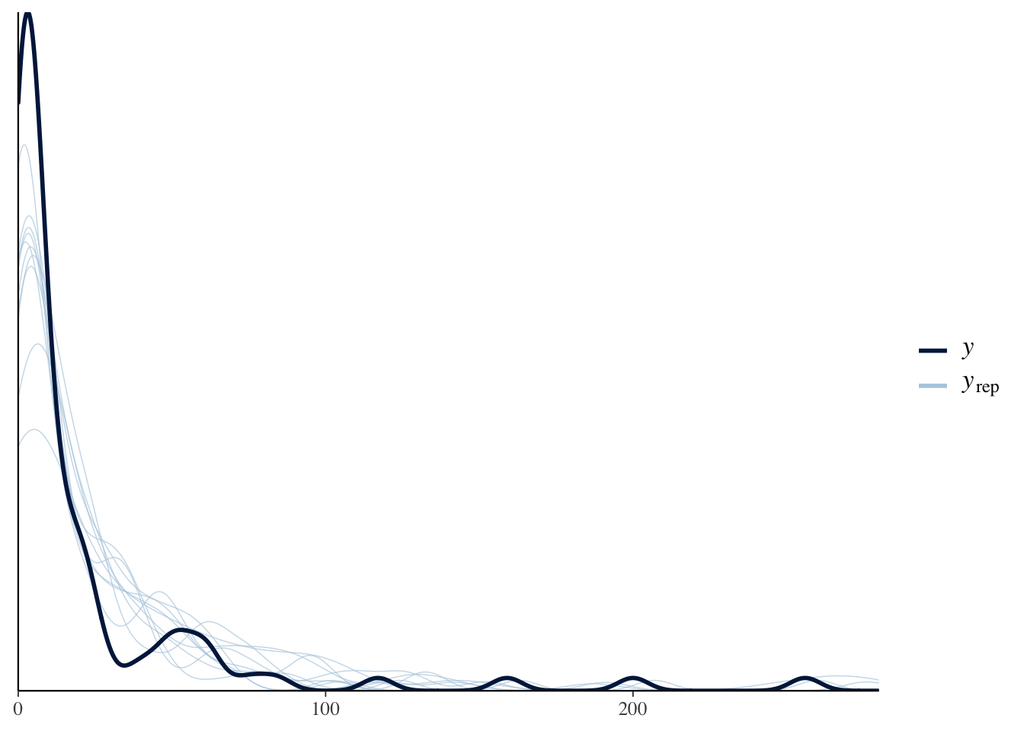

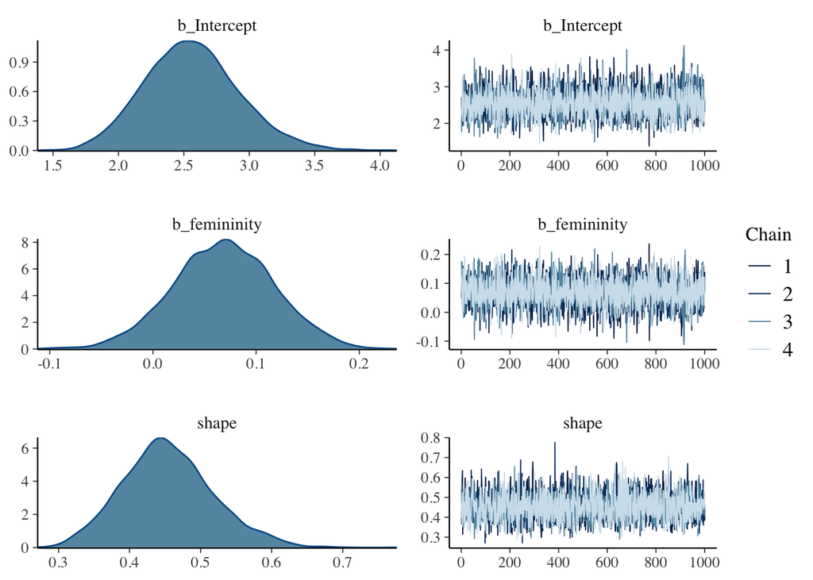

```r
plot(b12H2)
```

```r
summary(b12H2)
```

```
##  Family: negbinomial
##   Links: mu = log; shape = identity
## Formula: deaths ~ femininity
##    Data: Hurricanes (Number of observations: 92)
## Samples: 4 chains, each with iter = 2000; warmup = 1000; thin = 1;
##          total post-warmup samples = 4000
##
## Population-Level Effects:
##            Estimate Est.Error l-95% CI u-95% CI Rhat Bulk_ESS Tail_ESS
## Intercept      2.56      0.36     1.90     3.33 1.00     3485     2642
## femininity     0.07      0.05    -0.03     0.16 1.00     3556     2948
##
## Family Specific Parameters:
##       Estimate Est.Error l-95% CI u-95% CI Rhat Bulk_ESS Tail_ESS
## shape     0.45      0.06     0.34     0.59 1.00     3680     2638
##
## Samples were drawn using sampling(NUTS). For each parameter, Bulk_ESS
## and Tail_ESS are effective sample size measures, and Rhat is the potential
## scale reduction factor on split chains (at convergence, Rhat = 1).
```

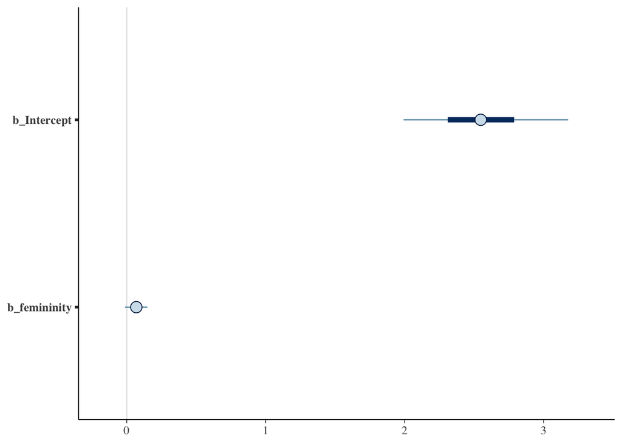

```r
mcmc_plot(b12H2, pars = "^b_")
```

```r
b12H2 <- add_criterion(b12H2, criterion = "loo")

b_loo <- loo_compare(b12.1, b12.1b, b12H2, criterion = "loo")

print(b_loo, simplify = F)
```

```
##        elpd_diff se_diff elpd_loo se_elpd_loo p_loo   se_p_loo looic   se_looic
## b12H2      0.0       0.0  -354.8     16.0         3.6     1.1    709.6    32.1
## b12.1b -1842.3     484.8 -2197.1    495.6       122.1    42.0   4394.1   991.1
## b12.1  -1858.6     522.8 -2213.4    533.4        67.6    26.6   4426.8  1066.8
```

```r
(post_predict_c<- fitted(b12H2,
         newdata = nd,
         probs = c(0.055,0.945)) %>%
  data.frame() %>%
  bind_cols(nd) %>%
     mutate(row = row_number()))
```

```
##    Estimate Est.Error      Q5.5    Q94.5 deaths femininity row
## 1  20.85387  3.317170 16.242329 26.81239      2    6.77778   1
## 2  14.92744  4.857752  8.986146 23.53286      4    1.38889   2
## 3  17.21604  3.754110 12.257036 23.90363      3    3.83333   3
## 4  26.02823  5.965900 18.147716 36.77964      1    9.83333   4
## 5  23.27784  4.217284 17.514049 30.86061      0    8.33333   5
## 6  22.90665  4.029757 17.411794 30.17572     60    8.11111   6
## 7  23.65793  4.423849 17.671210 31.64894     20    8.55556   7
## 8  25.27201  5.434040 18.037442 35.06561     20    9.44444   8
## 9  23.56206  4.370440 17.627976 31.45750      0    8.50000   9
## 10 26.13890  6.046288 18.157138 37.04589    200    9.88889  10
## 11 19.70938  3.218737 15.213750 25.37035      7    5.94444  11
## 12 21.17629  3.386624 16.447939 27.19797     15    7.00000  12
## 13 26.13890  6.046288 18.157138 37.04589      1    9.88889  13
## 14 26.13890  6.046288 18.157138 37.04589      0    9.88889  14
```

[output cut: 74 more lines]

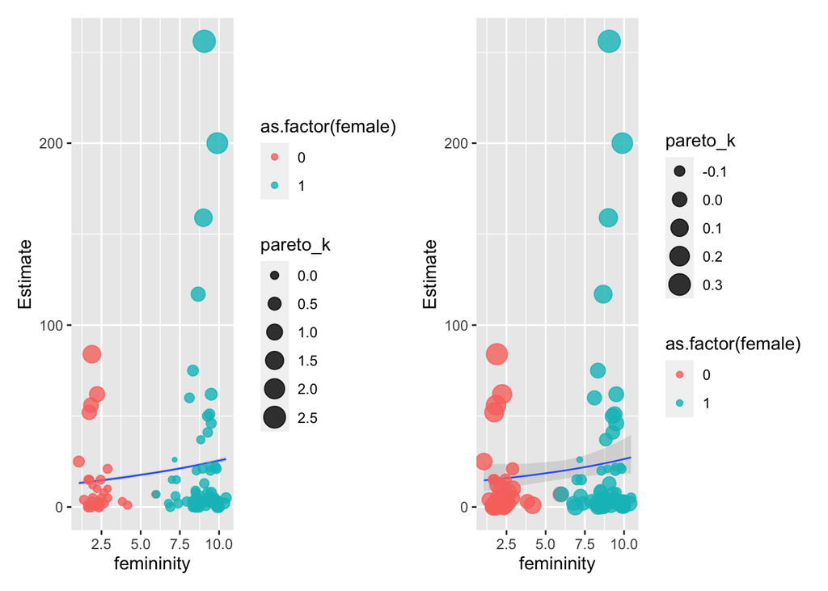

```r
p3 <- post_predict_c %>%
  ggplot(aes(x = femininity)) +
  geom_smooth(aes(y = Estimate, ymin = Q5.5, ymax = Q94.5),
              stat = "identity",
              alpha = 1/4, size = 1/2) +
  geom_point(data = bind_cols(Hurricanes, b12H2$criteria$loo$diagnostics),
             aes(y = deaths, size = pareto_k, color =as.factor(female)),
             alpha = 4/5)

(p2 | p3)
```

Now when comparing the poisson and the negative- binomial model we see that 89% interval that overlaps zero (but only marginally, it still seems like a trend to me?) The reason that femininity and deaths association diminished in strength is that in the pure Poisson model highly influential extreme points contribute more to defining the strength of the trend. In the new model, extreme storms are still influential, but now exert less influence on the observed trend. The gamma-Poisson model expects rate variation, and the estimated amount of variation is quite large, thus diminishing the associations strength.